# 4_genomics_with_R

This document is an extension and explanation of the *R exercises* in the book [Genomics with R](https://compgenomr.github.io/book/) for Dr. Wiggins’ Introductory Genomics course at Oklahoma State University.

The [Genomics with R](https://compgenomr.github.io/book/) book contains critical information, explains the statistics used, and provides the exercises.

This document is intended as a companion to the [Genomics with R](https://compgenomr.github.io/book/) book for students who are R beginners.

These instructions are for RStudio. In this course we are running RStudio through the Cyverse platform

This section begins with 4.1 Clustering: Grouping samples based on their similarity

#### Here I use the `package::function()` structure

except in the case of `base` and `utils` commands. This provides you with information about which package each function comes from. It makes code much more understandable and repeatable.

4.1.1 Distance metrics

In this section we use a data frame of patient gene expressions but how to create this table is not explained. Also, the data frame is called `df` this is problemmatic because tehre is a base R function `df` (the density of the F distribution). We will do the following

Name the data frame `exdf` for (gene)‘expression data frame.’

create the data frame with the following code. `data.frame` is the command that tells R what to do with what you put in the parentheses next. ‘Patient’, ‘IRX4’, ‘OCT4’, and ‘PAX6’ are the column names the information inside `c()` is what will go in the rows

```r
exdf <- data.frame(Patient <- c("Patient1", "Patient2", "Patient3", "Patient4"), IRX4 <- c(11, 13, 2, 1), OCT4 <- c(10, 13, 4, 3), PAX6 <- c(1, 3, 10, 9))
```

look at the data frame

```r
View(exdf)
```

Notice to the left <- of “Patient 1, Patient 2” etc are numbers. In R these are what is called the index.

We need to make the Patient designations the index.

```r
exdf2 <- exdf[-1]
row.names(exdf2) <- exdf$Patient
```

```r
View(exdf2)
```

Now the patien ID’s are the index

Calcluate the distance metrics

```r
stats::dist(exdf2, method = "manhattan")
```

```
##          Patient1 Patient2 Patient3
## Patient2        7
## Patient3       24       27
## Patient4       25       28        3
```

```r
stats::dist(exdf2, method = "euclidean")
```

```
##           Patient1  Patient2  Patient3
## Patient2  4.123106
## Patient3 14.071247 15.842980
## Patient4 14.594520 16.733201  1.732051
```

the correlation distance

```r
as.dist(1-cor(t(exdf2)))
```

```
##             Patient1    Patient2    Patient3
## Patient2 0.004129405
## Patient3 1.988522468 1.970725343
## Patient4 1.988522468 1.970725343 0.000000000
```

4.1.1.1 Scaling before calculating the distance

The book scales the data frame directly. This reduces the number of variables you have floating around in your environment but sometimes it might be worth it to create a new object so you don’t overwrite your data frame, in case you need to return to it later. Above, were I working with these data and not demonstrating I would have overwritten `exdf` rather than creating `exdf2` but I wanted both available for comparison.

```r
scaled_exdf2 <- scale(exdf2)
```

to view the distance matrix of the scaled data frame

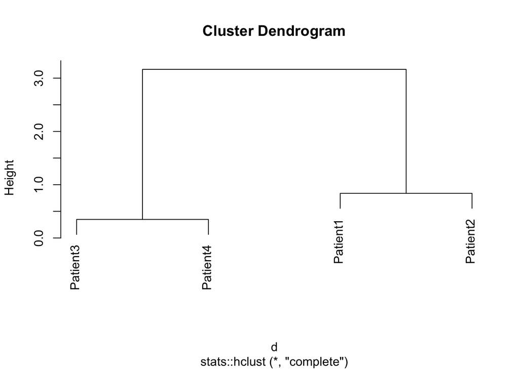

```r
#create an object to hold the scaled distance matrix
d <- stats::dist(scaled_exdf2)

#do hierarchical clustering
hc <- stats::hclust(d, method = "complete")

#plot the results
plot(hc)
```